# Exploratory Data Analysis

Damian Thomas

2016-09-16

## Welcome & Setup

1. Log in to network
2. Update course materials from github
3. Open lecture file
4. Set working directory

## Quick Assessment

What have data analysis software have students used in the past?

- Stata
- SAS
- Excel
- SPSS
- Matlab
- Other

Compare to the [broader trends](http://r4stats.com/articles/popularity/)

## Refereshers

### Rstudio – Four Panels and a Menu

The windows in the default layout can be broken down into two broad categories, according to their purpose.

1. Inputs from user
   - Console: interactive R prompt
   - Text Editor: view, create, and change contents of text files
2. Outputs from R
   - Console: interactive R prompt
   - Environment: current workspace, previous commands
   - Viewer: View plots, help documentation, etc.

### R Object types

- Vectors: one dimension, one type
- Lists: one dimension, many types
- Matrices: two dimensions, one type
- Data Frames: two dimensions, many types

### R syntax

- Objects: store information
- Functions: input and output objects, take parameters
- Everything is an object or a function, unless it’s an environment ([what’s an environment?](https://www.r-bloggers.com/what-is-an-r-environment/))

Subset objects by indexing.

Do things with objects using functions

### Reading Data

- Delimited text files (CSV, tab, text, etc): use base R functions, or functions from the readr package
- Excel, stata, etc.: use packages (foreign, etc.)
- unstructured data:

### Viewing Data

- Environment tab: click on the object
- print() function: type the object name at command prompt and press enter
- View() function: in RStudio

### Running Code

*TMTOWTDI: “There’s more than one way to do it”*

1. One line of code
   1. Console: type the command, press enter
   2. Editor:
      - select the text, then click **Run**
      - select the text, then press **Ctrl+Enter**
      - place the cursor on the line of code, then press **Ctrl+Enter**
2. Multiple lines of code
   1. Console: type commands separated by semicolons, press enter
   2. RStudio Editor:
      - select the text, then click **Run**
      - select the text, then press **Ctrl+Enter**
3. Entire program
   1. Console: use the **source()** function to execute commands saved in a file
   2. RStudio Editor:
      - open the file, then press **Ctrl+Shift+Enter**
      - open the file, then press the **Source** button
   3. Batch Mode (outside of RStudio)
      - go to system command prompt, then execute the command: **R CMD BATCH filename.R**
4. Markdown documents (e.g., lecture2.Rmd) open the file and press the **Knit HTML** button.

### Managing your Rstudio session

- Save workspace: write objects in memory to a file
  1. go to the **Environment** tab, then click on the blue disk icon
  2. go the **Session** menu, select **Save Workspace As**
  3. use the **save()** function
- Clear workspace: remove objects from memory
  1. go to the **Environment** tab, then click on the yellow broom icon
  2. go the **Session** menu, select **Load Workspace**
  3. use the **ls()** and **rm()** functions
- Reload saved workspace, or read objects that were saved to a file
  1. go to the **Environment** tab, then click on the yellow and green folder icon
  2. go the **Session** menu, select **Load Workspace**
  3. use the **load()** function
- Customize Appearance: go to **Tools** menu, then select **Global Options**, then choose **Appearance** (the paint bucket icon). From there you can choose a color theme for syntax highlighting and change the default font size.
- Set working directory

## Exploring Data

There are 3 major types of data set: time-series, cross-sectional, and panel or longitudinal.

### Time series Data

A single measure observed at different points in time.

“Most commonly, a *time series* is a sequence taken at successive equally spaced points in time. Thus it is a sequence of discrete-time data. Examples of time series are heights of ocean tides, counts of sunspots, and the daily closing value of the Dow Jones Industrial Average” ([Wikipedia, 2016-03-30](https://en.wikipedia.org/wiki/Time_series))

Examples: Unemployment rate, GDP, my height

### Step 1 - Get raw data from the source

The St. Louis Fed provides thousands of time series to the public (https://fred.stlouisfed.org/).

- Choose an example and download it as a csv file.
- Advanced option: use the quantmod package to download directly from R

```r
# install.packages(quantmod)
# if ( !file.exists() ) download.file()
```

### Step 2 - Look at the raw data file

- In RStudio, view the raw data.
  1. go the the **Files** tab (lower right)
  2. Navigate to the directory where you saved the file
  3. click on the file to view
- Notice: the dot “.” indicates missing values

### Step 3 - Read the raw data into R

Use what we learned about the raw data to read it into R

```r
# base R function
hhnw <- read.csv("data/TNWBSHNO.csv", na.strings = ".")
```

### Step 4 - Look at the raw data again (in R)

- Browse the data frame in Rstudio – use the object in the **Environment**
- Use R commands to print information about the data frame

```r
# View data "structure""
str(hhnw)
```

```
## 'data.frame':    282 obs. of  2 variables:
##  $ DATE    : Factor w/ 282 levels "1945-10-01","1946-01-01",..: 1 2 3 4 5 6 7 8 9 10 ...
##  $ TNWBSHNO: num  802 NA NA NA 880 ...
```

```r
# Print the first few rows of data
head(hhnw)
```

```
##         DATE TNWBSHNO
## 1 1945-10-01   802.37
## 2 1946-01-01       NA
## 3 1946-04-01       NA
## 4 1946-07-01       NA
## 5 1946-10-01   880.34
## 6 1947-01-01       NA
```

```r
# Print the last few rows of data
tail(hhnw)
```

```
##           DATE TNWBSHNO
## 277 2014-10-01 84200.59
## 278 2015-01-01 86019.48
## 279 2015-04-01 86500.00
## 280 2015-07-01 85069.35
## 281 2015-10-01 87249.54
## 282 2016-01-01 88086.94
```

From these commands we know a little bit about how the data

- Variable names
- Number of observations
- Data types
- The first few values
- There are missing values

### Step 5 - Data Cleaning

Problems

Fixes

1. Use options in read.csv
2. rename variables
3. Convert the Date variable from character type a date type.
4. Ignore for now. What to do about missing values depends on the research question.

```r
# start over
rm(hhnw)

# Read the raw file
hhnw <- read.csv("data/TNWBSHNO.csv", na.strings=".", stringsAsFactors = FALSE)

# Change names
names(hhnw) <- c("date", "level")

# Convert the character type into a date type
hhnw$date <- as.Date(hhnw$date, format="%Y-%m-%d")

# Look at the data
str(hhnw)
```

```
## 'data.frame':    282 obs. of  2 variables:
##  $ date : Date, format: "1945-10-01" "1946-01-01" ...
##  $ level: num  802 NA NA NA 880 ...
```

```r
head(hhnw)
```

```
##         date  level
## 1 1945-10-01 802.37
## 2 1946-01-01     NA
## 3 1946-04-01     NA
## 4 1946-07-01     NA
## 5 1946-10-01 880.34
## 6 1947-01-01     NA
```

```r
tail(hhnw)
```

```
##           date    level
## 277 2014-10-01 84200.59
## 278 2015-01-01 86019.48
## 279 2015-04-01 86500.00
## 280 2015-07-01 85069.35
## 281 2015-10-01 87249.54
## 282 2016-01-01 88086.94
```

Better?

### Step 6 - Numeric summaries

- Summary Statistics

```r
summary(hhnw$level)
```

```
##    Min. 1st Qu.  Median    Mean 3rd Qu.    Max.    NA's
##   802.4  2870.0 12400.0 23180.0 40600.0 88090.0      18
```

- summaries for subsets of data

```r
hhnw_pre_crisis <- subset(hhnw, hhnw$date < as.Date("2007-06-01"))
summary(hhnw_pre_crisis)
```

```
##       date                level
##  Min.   :1945-10-01   Min.   :  802.4
##  1st Qu.:1961-02-15   1st Qu.: 2544.5
##  Median :1976-07-01   Median : 7897.6
##  Mean   :1976-07-01   Mean   :16107.6
##  3rd Qu.:1991-11-16   3rd Qu.:24794.0
##  Max.   :2007-04-01   Max.   :67670.5
##                       NA's   :18
```

```r
hhnw_post_crisis <- subset(hhnw, hhnw$date >= as.Date("2007-06-01"))
summary(hhnw_post_crisis)
```

```
##       date                level
##  Min.   :2007-07-01   Min.   :54639
##  1st Qu.:2009-08-16   1st Qu.:61150
##  Median :2011-10-01   Median :66234
##  Mean   :2011-10-01   Mean   :69470
##  3rd Qu.:2013-11-16   3rd Qu.:80003
##  Max.   :2016-01-01   Max.   :88087
```

Answer questions about the data * what is the maximum value, and when did it occur? * what is the minimum value, and when did it occur? * compare the period before and after the crisis a. max values b. min values c. interquartile range d. trend e. mean f. standard deviation

```r
#...
```

### Step 6 - Visual presentation

- Line graph
- Histogram
- Boxplot

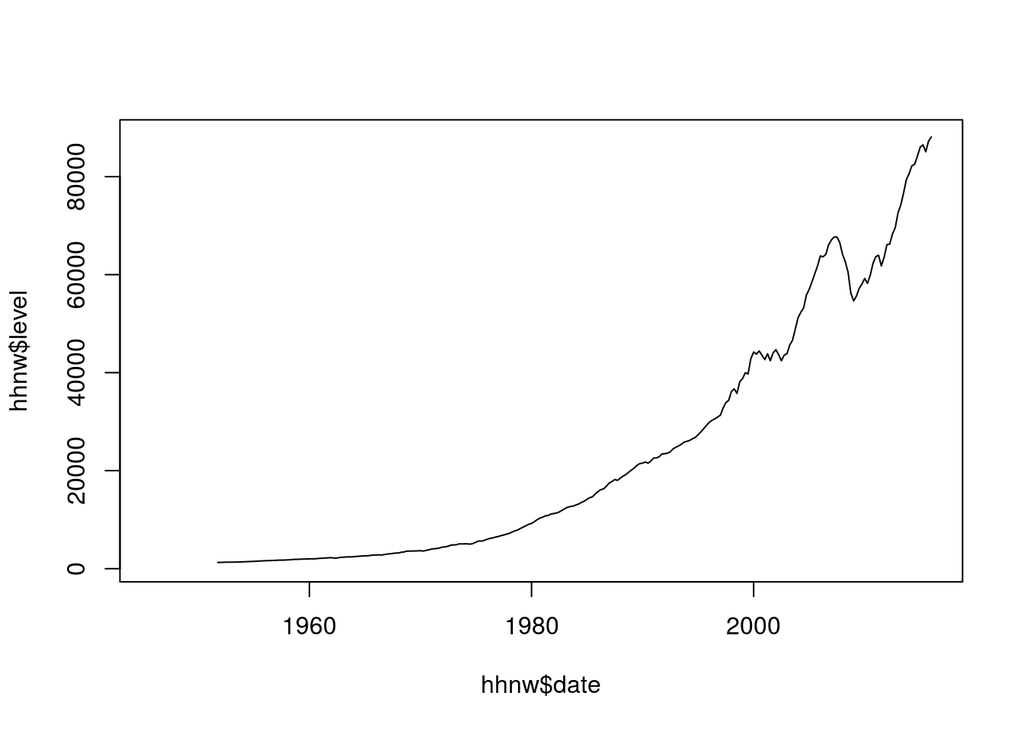

```r
# Visualize every observation with a line plot
plot(hhnw$date, hhnw$level, type = "l")
```

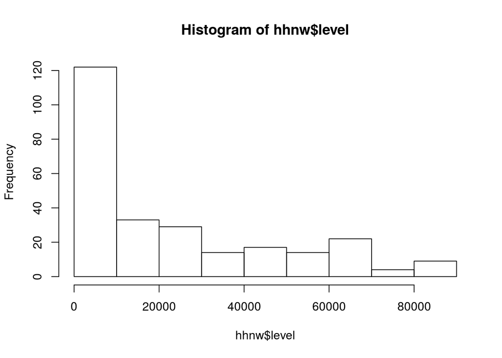

```r
# viualize distribution with histogram
hist(hhnw$level)
```

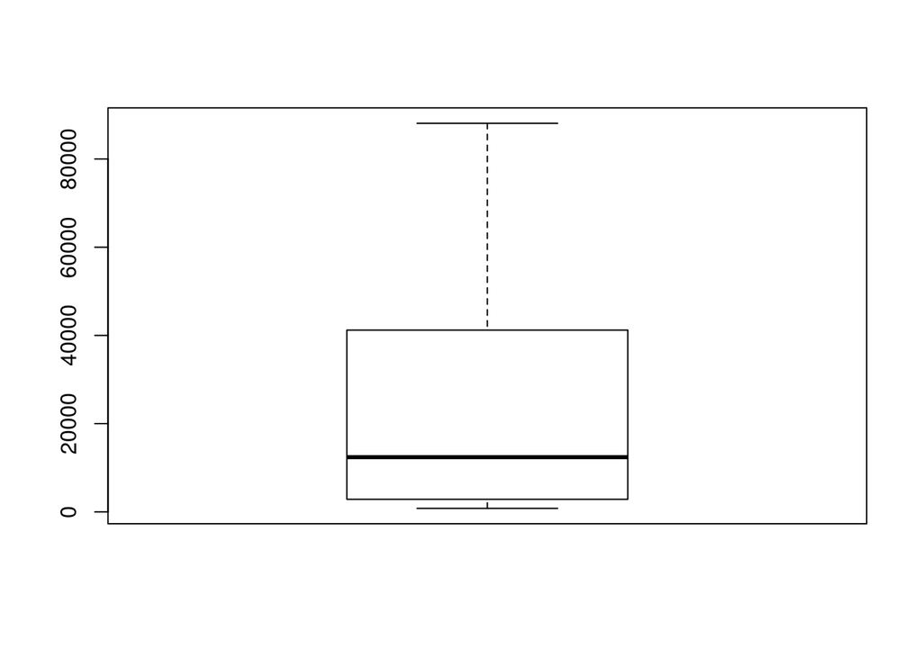

```r
# visualize distribution with boxplot
boxplot(hhnw$level)
```

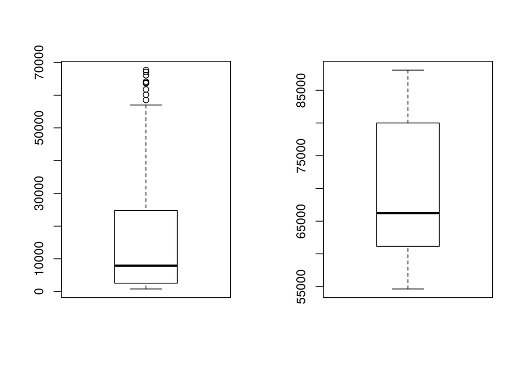

```r
# compare subsets with side-by-sde plots
par(mfrow=c(1,2))
boxplot(hhnw_pre_crisis$level)
boxplot(hhnw_post_crisis$level)
```

- advanced option: plot recessions with shading

### Cross Sectional Data

A single measure (or set of measures) observed from multiple entities at the same point in time.

“Cross-sectional data, or a cross section of a study population, in statistics and econometrics is a type of data collected by observing many subjects (such as individuals, firms, countries, or regions) at the same point of time, or without regard to differences in time. Analysis of cross-sectional data usually consists of comparing the differences among the subjects.” ([Wikipedia, 2016-03-30](https://en.wikipedia.org/wiki/Cross-sectional_data))

Examples: student GPAs,

### Panel Data

Cross sectional data from multiple points in time

“In statistics and econometrics, the term panel data refers to multi-dimensional data frequently involving measurements over time. Panel data contain observations of multiple phenomena obtained over multiple time periods for the same firms or individuals. In biostatistics, the term longitudinal data is often used instead, wherein a subject or cluster constitutes a panel member or individual in a longitudinal study. Time series and cross-sectional data can be thought of as special cases of panel data that are in one dimension only (one panel member or individual for the former, one time point for the latter).” ([Wikipedia, 2016-03-30](https://en.wikipedia.org/wiki/Panel_data))

- PSID, US Census, …

## Resources

https://www.rstudio.com/online-learning/#R

http://tryr.codeschool.com/

https://github.com/DataScienceSpecialization/courses/tree/master/04_ExploratoryAnalysis

http://r4ds.had.co.nz/

https://github.com/hadley/r4ds